# Project: Investigate a Dataset - [Gapminder World]

- Introduction
- Data Wrangling
- Exploratory Data Analysis
- Conclusions

## Introduction

### Dataset Description

> Gapminder has collected a lot of information about how people live their lives in different countries, tracked across the years, and on a number of different indicators. The tables used are child mortality(0-5 year-olds dying per 1000 born), income per person (GDP per Capita, PPP-dollar inflation-adjusted), and life expectancy years(the average number of years a newborn child would live).

### Questions for Analysis

> Have certain regions of the world been growing in some indicators better than others?

> Are there trends that can be observed between the indicators?

```python
import numpy as np
import pandas as pd
import matplotlib.pyplot as plt
import seaborn as sns
%matplotlib inline
plt.style.use('seaborn')
```

## Data Wrangling

```python
# Loading and printing out the three tables
df1 = pd.read_excel('child_mortality_0_5_year_olds_dying_per_1000_born.xlsx')
df1.head()
```

|  | country | 1800 | 1801 | 1802 | 1803 | 1804 | 1805 | 1806 | 1807 | 1808 | ... | 2091 | 2092 | 2093 | 2094 | 2095 | 2096 | 2097 | 2098 | 2099 | 2100 |
| --- | --- | --- | --- | --- | --- | --- | --- | --- | --- | --- | --- | --- | --- | --- | --- | --- | --- | --- | --- | --- | --- |
| 0 | Afghanistan | 469.0 | 469.0 | 469.0 | 469.0 | 469.0 | 469.0 | 470.0 | 470.0 | 470.0 | ... | 12.60 | 12.40 | 12.20 | 12.00 | 11.80 | 11.60 | 11.50 | 11.30 | 11.10 | 11.10 |
| 1 | Angola | 486.0 | 486.0 | 486.0 | 486.0 | 486.0 | 486.0 | 486.0 | 486.0 | 486.0 | ... | 17.70 | 17.50 | 17.30 | 17.10 | 17.00 | 16.80 | 16.60 | 16.40 | 16.30 | 16.30 |
| 2 | Albania | 375.0 | 375.0 | 375.0 | 375.0 | 375.0 | 375.0 | 375.0 | 375.0 | 375.0 | ... | 2.32 | 2.30 | 2.27 | 2.24 | 2.22 | 2.19 | 2.16 | 2.14 | 2.11 | 2.11 |
| 3 | Andorra | NaN | NaN | NaN | NaN | NaN | NaN | NaN | NaN | NaN | ... | 0.86 | 0.84 | 0.83 | 0.81 | 0.80 | 0.79 | 0.78 | 0.77 | 0.76 | 0.76 |
| 4 | United Arab Emirates | 434.0 | 434.0 | 434.0 | 434.0 | 434.0 | 434.0 | 434.0 | 434.0 | 434.0 | ... | 2.31 | 2.29 | 2.26 | 2.24 | 2.22 | 2.19 | 2.17 | 2.15 | 2.13 | 2.13 |

5 rows × 302 columns

```python
df1.shape
```

```
(197, 302)
```

```python
df2 = pd.read_excel('income_per_person_gdppercapita_ppp_inflation_adjusted.xlsx')
df2.head()
```

|  | country | 1800 | 1801 | 1802 | 1803 | 1804 | 1805 | 1806 | 1807 | 1808 | ... | 2041 | 2042 | 2043 | 2044 | 2045 | 2046 | 2047 | 2048 | 2049 | 2050 |
| --- | --- | --- | --- | --- | --- | --- | --- | --- | --- | --- | --- | --- | --- | --- | --- | --- | --- | --- | --- | --- | --- |
| 0 | Afghanistan | 683 | 683 | 683 | 683 | 683 | 683 | 683 | 683 | 683 | ... | 2690 | 2750 | 2810 | 2870 | 2930 | 2990 | 3060 | 3120 | 3190 | 3260 |
| 1 | Angola | 700 | 702 | 705 | 709 | 711 | 714 | 718 | 721 | 725 | ... | 8000 | 8170 | 8350 | 8530 | 8710 | 8900 | 9090 | 9280 | 9480 | 9690 |
| 2 | Albania | 755 | 755 | 755 | 755 | 755 | 756 | 756 | 756 | 756 | ... | 25.1k | 25.6k | 26.2k | 26.7k | 27.3k | 27.9k | 28.5k | 29.1k | 29.7k | 30.4k |
| 3 | Andorra | 1360 | 1360 | 1360 | 1360 | 1370 | 1370 | 1370 | 1370 | 1380 | ... | 68.9k | 70.4k | 71.9k | 73.4k | 75k | 76.6k | 78.3k | 80k | 81.7k | 83.4k |
| 4 | United Arab Emirates | 1130 | 1130 | 1140 | 1140 | 1150 | 1150 | 1160 | 1160 | 1160 | ... | 101k | 103k | 105k | 107k | 110k | 112k | 114k | 117k | 119k | 122k |

5 rows × 252 columns

```python
df2.shape
```

```
(195, 252)
```

```python
df3 = pd.read_excel('life_expectancy_years.xlsx')
df3.head()
```

|  | country | 1800 | 1801 | 1802 | 1803 | 1804 | 1805 | 1806 | 1807 | 1808 | ... | 2091 | 2092 | 2093 | 2094 | 2095 | 2096 | 2097 | 2098 | 2099 | 2100 |
| --- | --- | --- | --- | --- | --- | --- | --- | --- | --- | --- | --- | --- | --- | --- | --- | --- | --- | --- | --- | --- | --- |
| 0 | Afghanistan | 28.2 | 28.2 | 28.2 | 28.2 | 28.2 | 28.2 | 28.1 | 28.1 | 28.1 | ... | 75.5 | 75.7 | 75.8 | 76.0 | 76.1 | 76.2 | 76.4 | 76.5 | 76.6 | 76.8 |
| 1 | Angola | 27.0 | 27.0 | 27.0 | 27.0 | 27.0 | 27.0 | 27.0 | 27.0 | 27.0 | ... | 78.8 | 79.0 | 79.1 | 79.2 | 79.3 | 79.5 | 79.6 | 79.7 | 79.9 | 80.0 |
| 2 | Albania | 35.4 | 35.4 | 35.4 | 35.4 | 35.4 | 35.4 | 35.4 | 35.4 | 35.4 | ... | 87.4 | 87.5 | 87.6 | 87.7 | 87.8 | 87.9 | 88.0 | 88.2 | 88.3 | 88.4 |
| 3 | Andorra | NaN | NaN | NaN | NaN | NaN | NaN | NaN | NaN | NaN | ... | NaN | NaN | NaN | NaN | NaN | NaN | NaN | NaN | NaN | NaN |
| 4 | United Arab Emirates | 30.7 | 30.7 | 30.7 | 30.7 | 30.7 | 30.7 | 30.7 | 30.7 | 30.7 | ... | 82.4 | 82.5 | 82.6 | 82.7 | 82.8 | 82.9 | 83.0 | 83.1 | 83.2 | 83.3 |

5 rows × 302 columns

```python
df3.shape
```

```
(195, 302)
```

```python
df1=df1.melt(id_vars=["country"],var_name="year") # reshaping the tables to display the years and the indicators in columns
df2=df2.melt(id_vars=["country"],var_name="year")
df3=df3.melt(id_vars=["country"],var_name="year")
```

```python
df1.head()
```

|  | country | year | value |
| --- | --- | --- | --- |
| 0 | Afghanistan | 1800 | 469.0 |
| 1 | Angola | 1800 | 486.0 |
| 2 | Albania | 1800 | 375.0 |
| 3 | Andorra | 1800 | NaN |
| 4 | United Arab Emirates | 1800 | 434.0 |

```python
df2.head()
```

|  | country | year | value |
| --- | --- | --- | --- |
| 0 | Afghanistan | 1800 | 683 |
| 1 | Angola | 1800 | 700 |
| 2 | Albania | 1800 | 755 |
| 3 | Andorra | 1800 | 1360 |
| 4 | United Arab Emirates | 1800 | 1130 |

```python
df3.head()
```

|  | country | year | value |
| --- | --- | --- | --- |
| 0 | Afghanistan | 1800 | 28.2 |
| 1 | Angola | 1800 | 27.0 |
| 2 | Albania | 1800 | 35.4 |
| 3 | Andorra | 1800 | NaN |
| 4 | United Arab Emirates | 1800 | 30.7 |

```python
df12=pd.merge(df1,df2,on=['country','year']) # merging the first two tables
df=pd.merge(df12,df3,on=['country','year']) # merging the the third table with them
```

```python
df.head()
```

|  | country | year | value_x | value_y | value |
| --- | --- | --- | --- | --- | --- |
| 0 | Afghanistan | 1800 | 469.0 | 683 | 28.2 |
| 1 | Angola | 1800 | 486.0 | 700 | 27.0 |
| 2 | Albania | 1800 | 375.0 | 755 | 35.4 |
| 3 | Andorra | 1800 | NaN | 1360 | NaN |
| 4 | United Arab Emirates | 1800 | 434.0 | 1130 | 30.7 |

```python
df.rename(columns = {'value_x':'child_mortality_per_1000_born', 'value_y':'income_per_person',
                              'value':'life_expectancy_years'}, inplace = True) # renaming the indicators columns
df.head()
```

|  | country | year | child_mortality_per_1000_born | income_per_person | life_expectancy_years |
| --- | --- | --- | --- | --- | --- |
| 0 | Afghanistan | 1800 | 469.0 | 683 | 28.2 |
| 1 | Angola | 1800 | 486.0 | 700 | 27.0 |
| 2 | Albania | 1800 | 375.0 | 755 | 35.4 |
| 3 | Andorra | 1800 | NaN | 1360 | NaN |
| 4 | United Arab Emirates | 1800 | 434.0 | 1130 | 30.7 |

```python
df.value_counts(df['country']).tail(11)
```

```
country
Guyana           251
Gambia           251
Georgia          251
Germany          251
Ghana            251
Greece           251
Grenada          251
Guatemala        251
Guinea           251
Guinea-Bissau    251
Zimbabwe         251
dtype: int64
```

```python
df.info()
```

```
<class 'pandas.core.frame.DataFrame'>
Int64Index: 48945 entries, 0 to 48944
Data columns (total 5 columns):
 #   Column                         Non-Null Count  Dtype
---  ------                         --------------  -----
 0   country                        48945 non-null  object
 1   year                           48945 non-null  object
 2   child_mortality_per_1000_born  47445 non-null  float64
 3   income_per_person              48945 non-null  object
 4   life_expectancy_years          47316 non-null  float64
dtypes: float64(2), object(3)
memory usage: 2.2+ MB
```

```python
df.isna().sum() # checking missing values
```

```
country                             0
year                                0
child_mortality_per_1000_born    1500
income_per_person                   0
life_expectancy_years            1629
dtype: int64
```

```python
df=df.dropna().reset_index(drop=True) # dropping the missing values
df.head()
```

|  | country | year | child_mortality_per_1000_born | income_per_person | life_expectancy_years |
| --- | --- | --- | --- | --- | --- |
| 0 | Afghanistan | 1800 | 469.0 | 683 | 28.2 |
| 1 | Angola | 1800 | 486.0 | 700 | 27.0 |
| 2 | Albania | 1800 | 375.0 | 755 | 35.4 |
| 3 | United Arab Emirates | 1800 | 434.0 | 1130 | 30.7 |
| 4 | Argentina | 1800 | 402.0 | 1730 | 33.2 |

```python
df.value_counts(df['country']).tail(11) # there are some countries having incomplete data for the whole duration of the years
```

```
country
Greece                 251
Hong Kong, China       101
Andorra                 70
Dominica                70
Nauru                   70
Marshall Islands        70
Tuvalu                  70
Monaco                  70
St. Kitts and Nevis     70
Palau                   70
San Marino              70
dtype: int64
```

```python
df=df[df['country'].isin(['Hong Kong, China','Andorra','Dominica','Nauru','Marshall Islands',
'Tuvalu','Monaco','St. Kitts and Nevis','Palau','San Marino']) == False].reset_index(drop=True)
df.head()                                             # dropping the countries having incomplete data
```

|  | country | year | child_mortality_per_1000_born | income_per_person | life_expectancy_years |
| --- | --- | --- | --- | --- | --- |
| 0 | Afghanistan | 1800 | 469.0 | 683 | 28.2 |
| 1 | Angola | 1800 | 486.0 | 700 | 27.0 |
| 2 | Albania | 1800 | 375.0 | 755 | 35.4 |
| 3 | United Arab Emirates | 1800 | 434.0 | 1130 | 30.7 |
| 4 | Argentina | 1800 | 402.0 | 1730 | 33.2 |

```python
df.dtypes # the type of the income_per_person column is object. So, it has to be converted into a numeric type
```

```
country                           object
year                              object
child_mortality_per_1000_born    float64
income_per_person                 object
life_expectancy_years            float64
dtype: object
```

```python
income=[]                                                      # converting the object type of the column into a numeric type
for i in df['income_per_person']:
    if type(i)==str:
            i=i.replace('k','')
            income.append(float(i)*1000)
    else:
        income.append(i)
```

```python
df['income_per_person']=income             # replacing the object column with the numeric column
df
```

|  | country | year | child_mortality_per_1000_born | income_per_person | life_expectancy_years |
| --- | --- | --- | --- | --- | --- |
| 0 | Afghanistan | 1800 | 469.0 | 683.0 | 28.2 |
| 1 | Angola | 1800 | 486.0 | 700.0 | 27.0 |
| 2 | Albania | 1800 | 375.0 | 755.0 | 35.4 |
| 3 | United Arab Emirates | 1800 | 434.0 | 1130.0 | 30.7 |
| 4 | Argentina | 1800 | 402.0 | 1730.0 | 33.2 |
| ... | ... | ... | ... | ... | ... |
| 46430 | Samoa | 2050 | 7.1 | 10700.0 | 74.3 |
| 46431 | Yemen | 2050 | 28.8 | 4540.0 | 72.2 |
| 46432 | South Africa | 2050 | 18.3 | 19700.0 | 70.9 |
| 46433 | Zambia | 2050 | 24.7 | 5680.0 | 69.8 |
| 46434 | Zimbabwe | 2050 | 24.2 | 5920.0 | 67.6 |

46435 rows × 5 columns

```python
avg_child_mortality=[]
avg_income=[]
avg_life_years=[]
for i in df['country'][:185] :
    avg_child_mortality_value=df[df['country']==i]['child_mortality_per_1000_born'].rolling(20, min_periods=1).mean()
    avg_child_mortality.append(avg_child_mortality_value)

    avg_income_value=df[df['country']==i]['income_per_person'].rolling(20, min_periods=1).mean()
    avg_income.append(avg_income_value)

    avg_life_years_value=df[df['country']==i]['life_expectancy_years'].rolling(20, min_periods=1).mean()
    avg_life_years.append(avg_life_years_value)                   # calculating 20-year moving averages for the three indicators
```

```python
avg_child_mortality=avg_child_mortality[0].append(avg_child_mortality[1:]).sort_index()
avg_income=avg_income[0].append(avg_income[1:]).sort_index() # making every list as one list instead of list of lists
avg_life_years=avg_life_years[0].append(avg_life_years[1:]).sort_index()
```

```python
df.insert(3,"avg_child_mortality",avg_child_mortality) # adding the columns of the moving averages
df.insert(5,"avg_income",avg_income)
df.insert(7,"avg_life_years",avg_life_years)
df.head()
```

|  | country | year | child_mortality_per_1000_born | avg_child_mortality | income_per_person | avg_income | life_expectancy_years | avg_life_years |
| --- | --- | --- | --- | --- | --- | --- | --- | --- |
| 0 | Afghanistan | 1800 | 469.0 | 469.0 | 683.0 | 683.0 | 28.2 | 28.2 |
| 1 | Angola | 1800 | 486.0 | 486.0 | 700.0 | 700.0 | 27.0 | 27.0 |
| 2 | Albania | 1800 | 375.0 | 375.0 | 755.0 | 755.0 | 35.4 | 35.4 |
| 3 | United Arab Emirates | 1800 | 434.0 | 434.0 | 1130.0 | 1130.0 | 30.7 | 30.7 |
| 4 | Argentina | 1800 | 402.0 | 402.0 | 1730.0 | 1730.0 | 33.2 | 33.2 |

## Exploratory Data Analysis

### Have certain regions of the world been growing in some indicators better than others?

```python
def plot(countries,indicator):
    for i in countries:
        plt.rcParams["figure.figsize"] = (20,10)
        plt.plot(df['year'].unique(),df[df['country']==i][indicator],label=i)
        plt.xlabel('year', fontsize=18)
        if indicator=='avg_child_mortality':
            plt.title('20-Year MA of child mortality per 1000 born', fontsize=22)
            plt.ylabel('child mortality per 1000 born', fontsize=18)

        elif indicator=='avg_income':
            plt.title('20-Year MA of income per person', fontsize=22)
            plt.ylabel('income per person', fontsize=18)

        elif indicator=='avg_life_years':
            plt.title('20-Year MA of life expectancy years', fontsize=22)
            plt.ylabel('life expectancy years', fontsize=18)

                    # defining a function for visualizing the moving averages of the indicators of countries across years
        plt.legend(fontsize=20)
```

##### The plot below clarifies that the Scandinavian countries have been shrinking in child mortality much better than the Latin American countries, especially in the last two centuries.

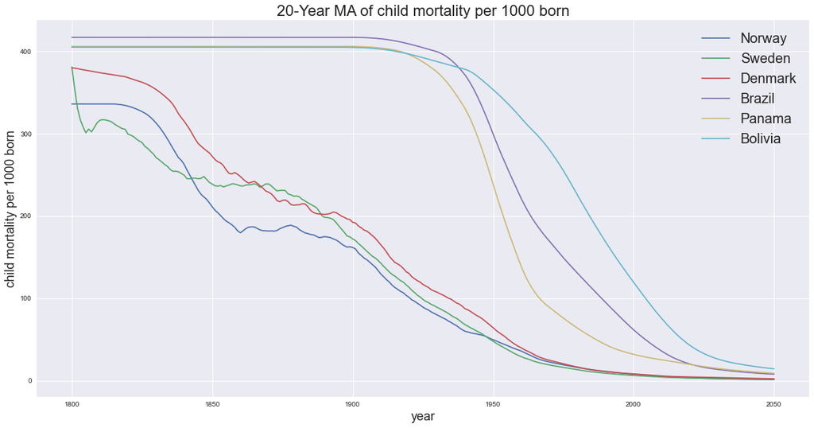

```python
plot(['Norway','Sweden','Denmark','Brazil','Panama','Bolivia'],'avg_child_mortality')
```

##### The plot below clarifies that the countries of East Asia have been growing in incomes much better than the African countries beginning from the second half of the twentieth century.

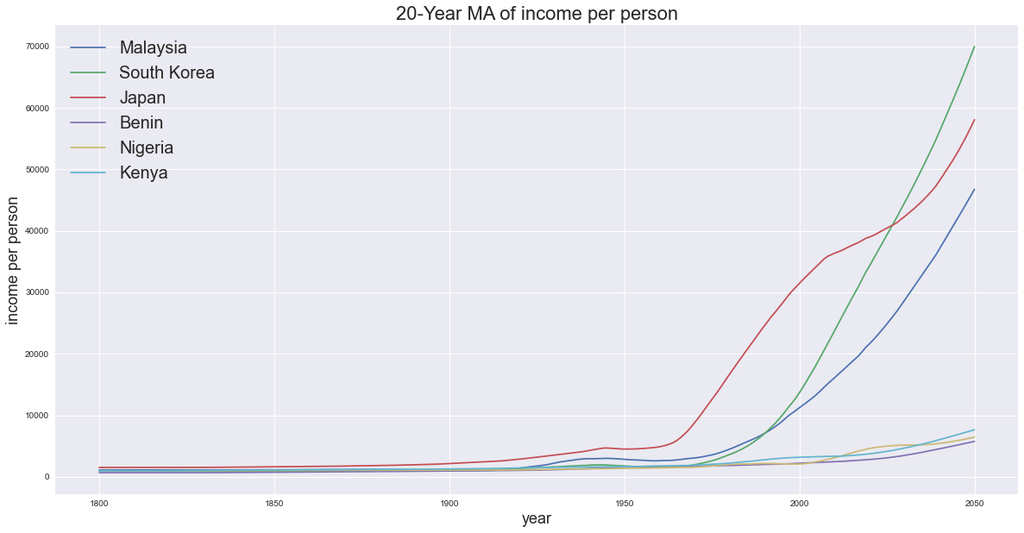

```python
plot(['Malaysia','South Korea','Japan','Benin','Nigeria','Kenya'],'avg_income')
```

##### The plot below clarifies that the Western countries have been growing in life expectancy years much better than the countries of Central Asia, including the last two centuries and the first half of the current century.

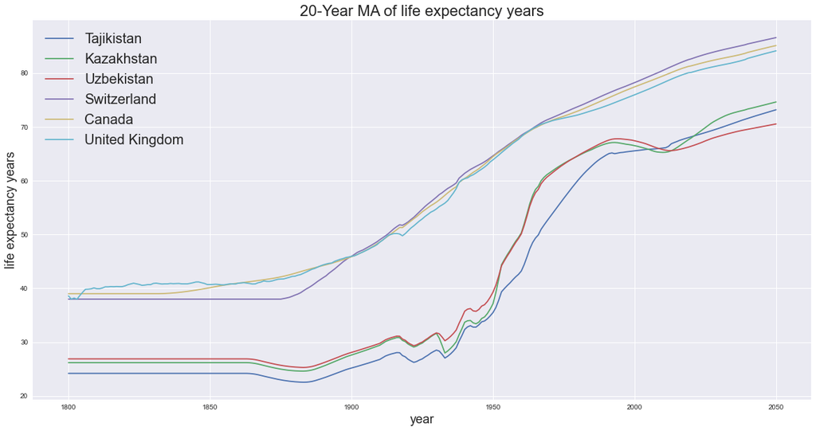

```python
plot(['Tajikistan','Kazakhstan','Uzbekistan','Switzerland','Canada','United Kingdom'],'avg_life_years')
```

### Are there trends that can be observed between the indicators?

##### In the plots below, it can be observed that there are a negative correlation between the average child mortality and the average incomes, a negative correlation between the average child mortality and the average life expectency years, and a positive correlation between the average incomes and the average life expectency years.

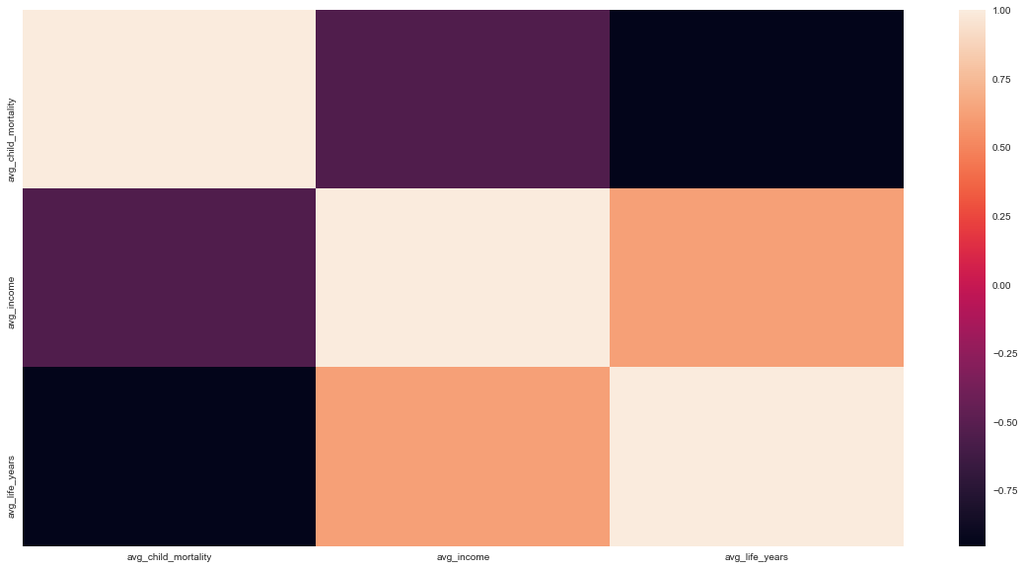

```python
sns.heatmap(df[['avg_child_mortality','avg_income','avg_life_years']].corr());
```

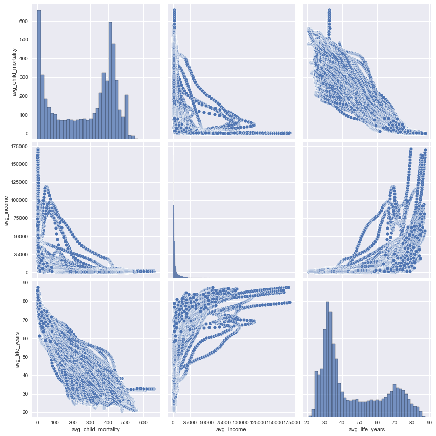

```python
sns.pairplot(df[['avg_child_mortality','avg_income','avg_life_years']],height=4);
```

##### The table below shows the correlation coefficients of the indicators.

```python
df[['avg_child_mortality','avg_income','avg_life_years']].corr()
```

|  | avg_child_mortality | avg_income | avg_life_years |
| --- | --- | --- | --- |
| avg_child_mortality | 1.000000 | -0.546487 | -0.953014 |
| avg_income | -0.546487 | 1.000000 | 0.623191 |
| avg_life_years | -0.953014 | 0.623191 | 1.000000 |

## Conclusions

> The East Asia and Western countries have positive indicators much better than the African, Central Asia and Latin Americans countries.

> The correlation coefficients of the indicators are -0.55 for the correlation which is between the average child mortality and the average incomes, -0.95 for the correlation which is between the average child mortality and the average life expectency years, and 0.62 for the correllation which is between the average incomes and the average life expectency years.

> The limitation of the dataset is that some countries have missing values in their data.

## References

> stackoverflow, geeksforgeeks, w3schools, pandas, and towardsdatascience websites.